# Project 1

# Introduction

Philisophy is the study of the fundamental nature of knowledge, reality, and existence. Today, I’m going to use the philisophy dataset to analysis the similarities and difference between schools. I’m going to take three different approaches in this blog.

- Which school is more popular in what stages of time
- Ideas and focus of schools
- Emtional aspect of schools

# Understanding Features and Varaibles in data

Data Preview:

|  | title | author | school | sentence_spacy | sentence_str | original_publication_date | corpus_edition_date | sentence_length | sentence_lowered | tokenized_txt | lemmatized_str |
| --- | --- | --- | --- | --- | --- | --- | --- | --- | --- | --- | --- |
| 1 | Plato - Complete Works | Plato | plato | What's new, Socrates, to make you leave your usual haunts in the Lyceum and spend your time here by the king archon's court? | What's new, Socrates, to make you leave your usual haunts in the Lyceum and spend your time here by the king archon's court? | -350 | 1997 | 125 | what's new, socrates, to make you leave your usual haunts in the lyceum and spend your time here by the king archon's court? | ['what', 'new', 'socrates', 'to', 'make', 'you', 'leave', 'your', 'usual', 'haunts', 'in', 'the', 'lyceum', 'and', 'spend', 'your', 'time', 'here', 'by', 'the', 'king', 'archon', 'court'] | what be new , Socrates , to make -PRON- leave -PRON- usual haunt in the Lyceum and spend -PRON- time here by the king archon 's court ? |
| 2 | Plato - Complete Works | Plato | plato | Surely you are not prosecuting anyone before the king archon as I am? | Surely you are not prosecuting anyone before the king archon as I am? | -350 | 1997 | 69 | surely you are not prosecuting anyone before the king archon as i am? | ['surely', 'you', 'are', 'not', 'prosecuting', 'anyone', 'before', 'the', 'king', 'archon', 'as', 'am'] | surely -PRON- be not prosecute anyone before the king archon as -PRON- be ? |
| 3 | Plato - Complete Works | Plato | plato | The Athenians do not call this a prosecution but an indictment, Euthyphro. | The Athenians do not call this a prosecution but an indictment, Euthyphro. | -350 | 1997 | 74 | the athenians do not call this a prosecution but an indictment, euthyphro. | ['the', 'athenians', 'do', 'not', 'call', 'this', 'prosecution', 'but', 'an', 'indictment', 'euthyphro'] | the Athenians do not call this a prosecution but an indictment , Euthyphro . |
| 4 | Plato - Complete Works | Plato | plato | What is this you say? | What is this you say? | -350 | 1997 | 21 | what is this you say? | ['what', 'is', 'this', 'you', 'say'] | what be this -PRON- say ? |
| 5 | Plato - Complete Works | Plato | plato | Someone must have indicted you, for you are not going to tell me that you have indicted someone else. | Someone must have indicted you, for you are not going to tell me that you have indicted someone else. | -350 | 1997 | 101 | someone must have indicted you, for you are not going to tell me that you have indicted someone else. | ['someone', 'must', 'have', 'indicted', 'you', 'for', 'you', 'are', 'not', 'going', 'to', 'tell', 'me', 'that', 'you', 'have', 'indicted', 'someone', 'else'] | someone must have indict -PRON- , for -PRON- be not go to tell -PRON- that -PRON- have indict someone else . |
| 6 | Plato - Complete Works | Plato | plato | But someone else has indicted you? | But someone else has indicted you? | -350 | 1997 | 34 | but someone else has indicted you? | ['but', 'someone', 'else', 'has', 'indicted', 'you'] | but someone else have indict -PRON- ? |

A summary of all features:

```
##     title              author             school          sentence_spacy
##  Length:360808      Length:360808      Length:360808      Length:360808
##  Class :character   Class :character   Class :character   Class :character
##  Mode  :character   Mode  :character   Mode  :character   Mode  :character
##
##
##
##  sentence_str       original_publication_date corpus_edition_date
##  Length:360808      Min.   :-350              Min.   :1887
##  Class :character   1st Qu.:1641              1st Qu.:1991
##  Mode  :character   Median :1817              Median :2001
##                     Mean   :1327              Mean   :1995
##                     3rd Qu.:1949              3rd Qu.:2007
##                     Max.   :1985              Max.   :2016
##  sentence_length  sentence_lowered   tokenized_txt      lemmatized_str
##  Min.   :  20.0   Length:360808      Length:360808      Length:360808
##  1st Qu.:  75.0   Class :character   Class :character   Class :character
##  Median : 127.0   Mode  :character   Mode  :character   Mode  :character
##  Mean   : 150.8
##  3rd Qu.: 199.0
##  Max.   :2649.0
```

Schools:

```
##  [1] "plato"           "aristotle"       "empiricism"      "rationalism"
##  [5] "analytic"        "continental"     "phenomenology"   "german_idealism"
##  [9] "communism"       "capitalism"      "stoicism"        "nietzsche"
## [13] "feminism"
```

Authors:

```
##  [1] "Plato"           "Aristotle"       "Locke"           "Hume"
##  [5] "Berkeley"        "Spinoza"         "Leibniz"         "Descartes"
##  [9] "Malebranche"     "Russell"         "Moore"           "Wittgenstein"
## [13] "Lewis"           "Quine"           "Popper"          "Kripke"
## [17] "Foucault"        "Derrida"         "Deleuze"         "Merleau-Ponty"
## [21] "Husserl"         "Heidegger"       "Kant"            "Fichte"
## [25] "Hegel"           "Marx"            "Lenin"           "Smith"
## [29] "Ricardo"         "Keynes"          "Epictetus"       "Marcus Aurelius"
## [33] "Nietzsche"       "Wollstonecraft"  "Beauvoir"        "Davis"
```

# Data analysis - Publication date

In this step we are going to first look at the distribution of data, when did the quotes in the dataset are being published, who and which school wrote the most quotes

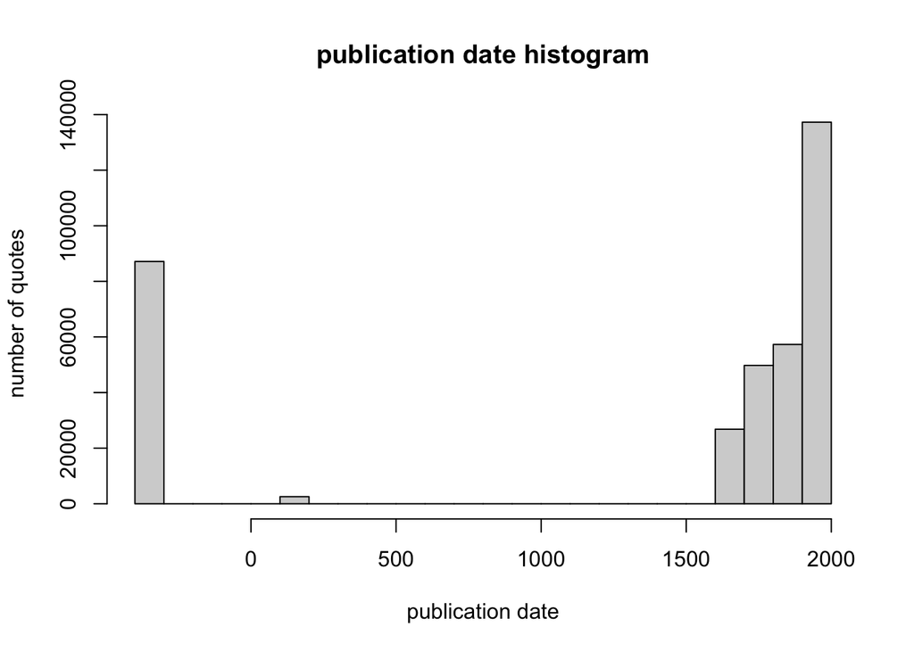

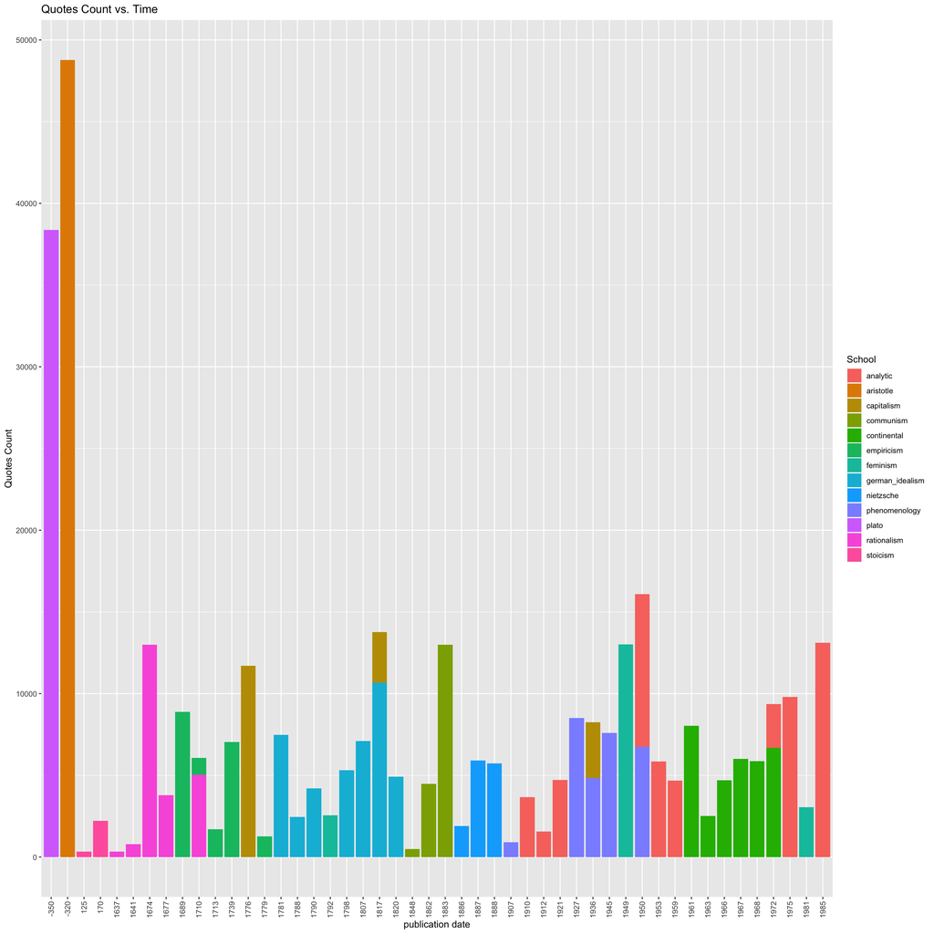

# Data Processing

In the next couple stages, we are going to look at the ideas and emotions of different philisophy schools. Since the dataset are too large, I’m going to randomly sample 1000 quotes from each school (13000 qutoes in total) for further processing.

After sampled, I’ll generate two new dataset using the sample generated:

- generate emotional data with eight basic emotions (anger, fear, anticipation, trust, surprise, sadness, joy, and disgust) and two sentiments (negative and positive) that is associated with word in each quote.
- generate a corpus of words for different school after data clean-up (map to lower case, remove numbers, puncuations, extra whitespaces, and stop words) for furthure visualizing a word cloud of ideas focus of each school.

# Data analysis - Main Idea of each school (Word cloud)

## Feminism

Feminism address such as the body, class and work, disability, the family, reproduction, the self, sex work, human trafficking, and sexuality. We can see that the most frequent word is women/woman, mother, lift, black, and work. Illisutring the ideas of balancing the life of women and a wish the achieve full gender equality.

[interactive chart not shown]

## Empiricism

Empiricism is the idea that all learning comes from only experience and observations. The top frequent words are ‘idea’, ‘will’, ‘can’, ‘make’. The word ‘make’ stood out for empiricim but not other schools, symbolized the experimental ideas of Empiricism.

[interactive chart not shown]

## Capitalism

The top frequent word for capitalism is: “price”, “labour”, “employ”, “countri”, and “canpart” which shapes the idea of private ownership, production, the motive to make a profit.

[interactive chart not shown]

## German idealism

The top frequent word for German idealism is: “one”, “concsious”, “concept”, “object”, “conscious”, “form”, and “reason”. This shapes the german idealism’s idea of nothing exists without the mind.

[interactive chart not shown]

## Nietzsche

The top frequent word for Nietzsche is: “one”, “will”, “life”, even“,”man“,”love“,”god“,”truth",which shape the idea of believing is self and science in contrast to god of Nietzsche.

[interactive chart not shown]

## Stoicism

The top frequent word for stocism is: “thing”, “thou”, “natur”, unto“,”thyself“,”life“,”proper", which shapes the belif of that for human beings virtue is the only good for stoicism.

[interactive chart not shown]

## Continental

The top frequent word for continental is: “one”, “form”, “differ”, “relate”, “order”, “mad”, “thought”, “element”, which shapes the belief of self and self-consciousness, freedom, desire and the will of continental.

[interactive chart not shown]

## Aristotle

The top frequent word for aristotle is: “differ”, “become”, “part”, “will”, “belong”, which shapes the belief of that “living well’ as the primary goal in human life” for aristotle.

[interactive chart not shown]

## Rationalism

The top frequent word for rationlism is: “must”, “can”, “since”, “time”, “will”, “bodi”, “sense”, “thing”, “way”, “much”, which shapes the idea of belief of opinions and actions should be based on reason and knowledge rather than on religious belief or emotional response of rationalism.

[interactive chart not shown]

## Plato

The top frequent word for plato is: “good”, “man”, “think”, “must”, “dont”, “god”. Which shapes plato’s belief of “happiness or well-being is the highest aim of moral thought and conduct, and the virtues are the requisite skills and dispositions needed to attain it”.

[interactive chart not shown]

## Communism

The top frequent word for communism is: “product”, “labour”, “work”, “hour”, “time”, “power”, “social”, which shapes the idea of everyone work together, spend time and acheive better life in communism.

[interactive chart not shown]

## Phenomenology

The top frequent word for phenomenology is: “world”, “present”, “exist” subject“,”science", which shapes the belief of analyzing daily human behavior can provide one with a greater understanding of nature for phenomenlogy.

[interactive chart not shown]

## Analytic

The top frequent word for analytic is: “true”, “realte”, “theory”, “mean”, “fact”, which shapes the idea of making use of formal logic and mathematics, and, to a lesser degree, the natural sciences for analytic.

[interactive chart not shown]

The words “one”, “exist”, “thing”, “man” appears frequently in almost all the schools, shaping the philiosphy idea of seek to understand fundamental truths about ourselves, as human.

# Data analysis - Emotions of each school (cluster)

In this step we are going to look at the emotions of philisophy quotes. Among all the sampled philisophy quotes, the emotion “Trust” stood out. Trust is very important in human development, without trust the human society will not be as developed as today.

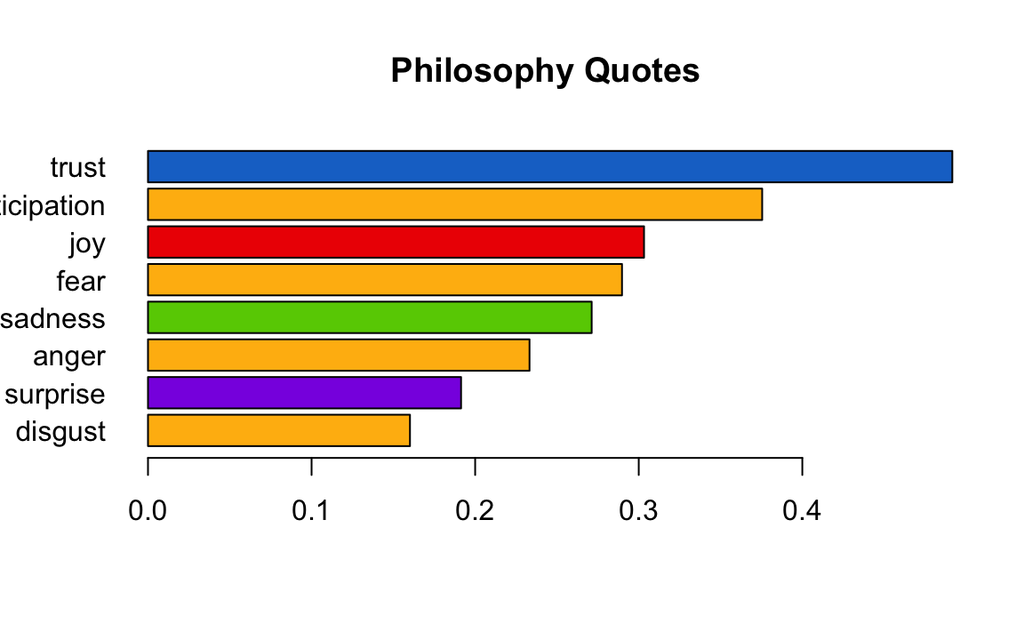

I also have plotted the emotion distribution for each school. Trust and anticipation is the main emotion for all school. Some schools have more focus on the joy side and have more a joyful tone, such as empiricism, capitalism, german idealism, nietzsche, stocism, aristotle, rationalism, plato, and communism. In contrast, continental, phenomenlogy, and analytic have more emotion on sadness and fear.

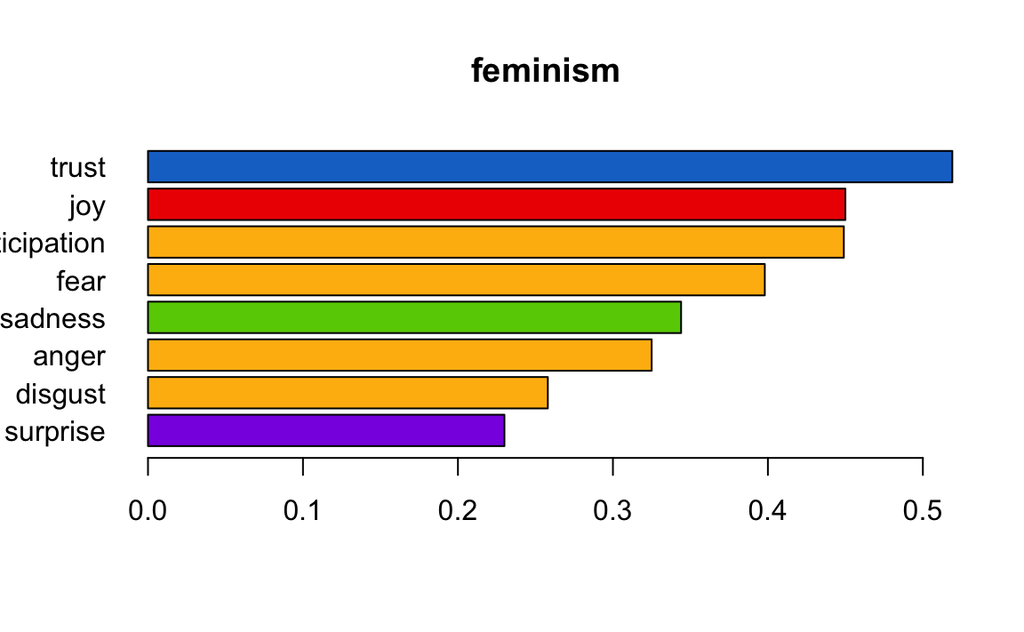

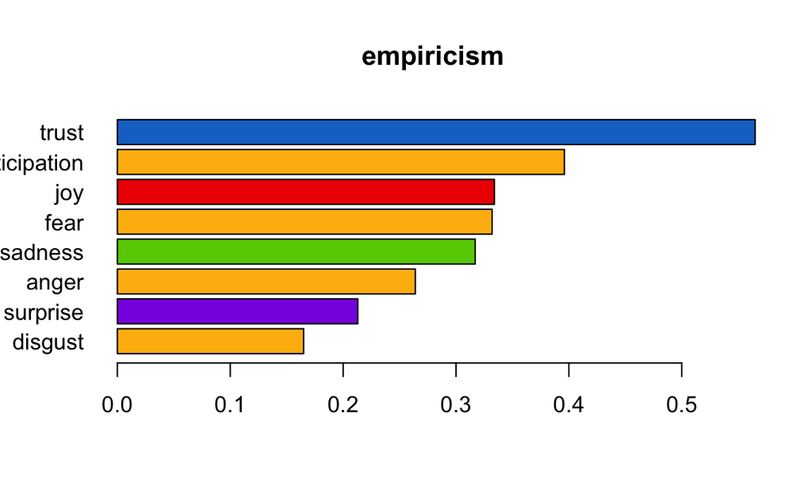

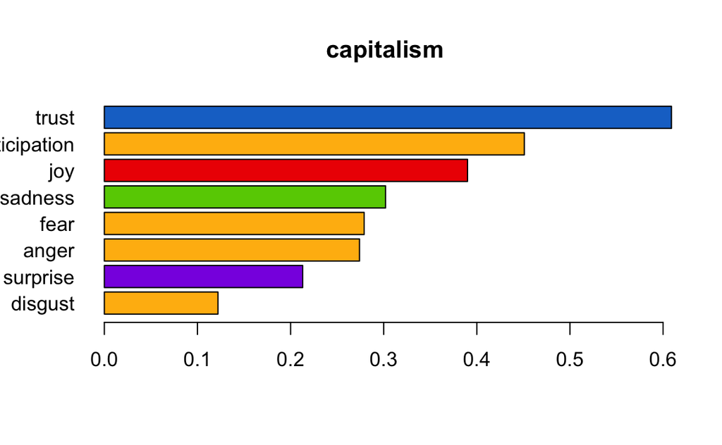

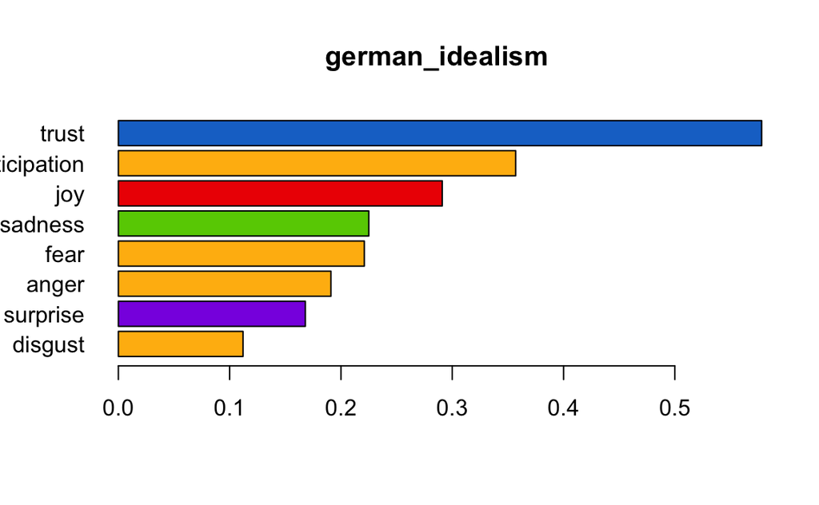

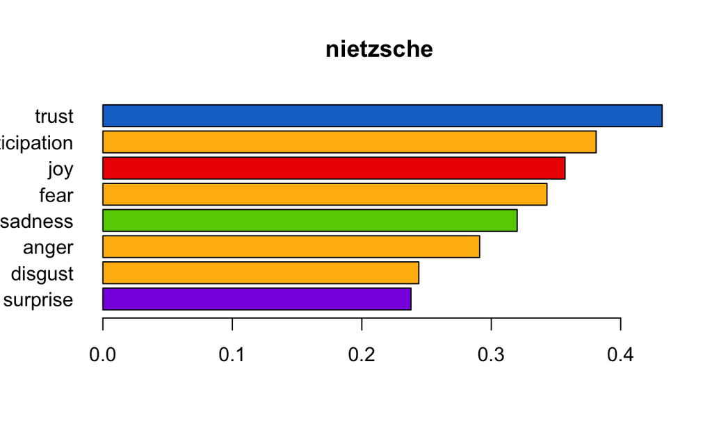

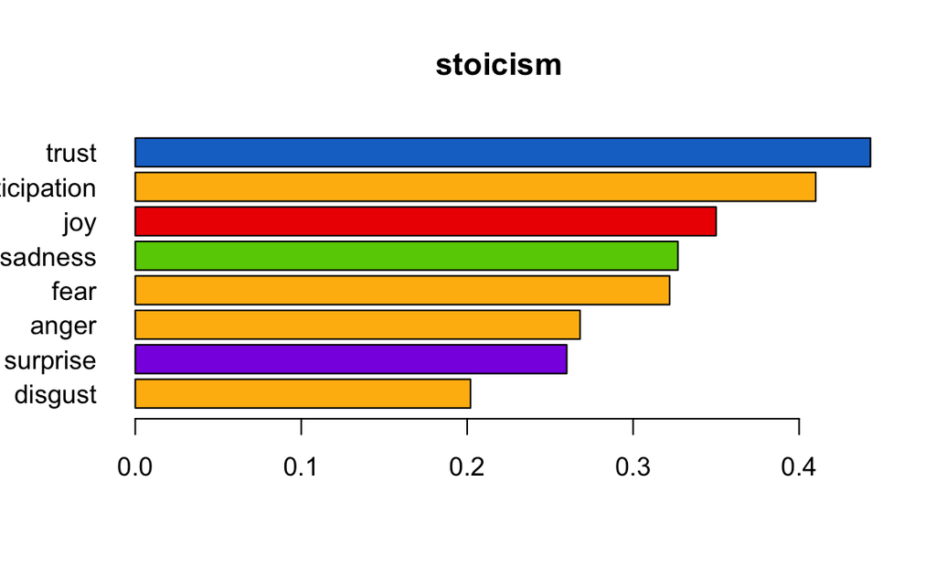

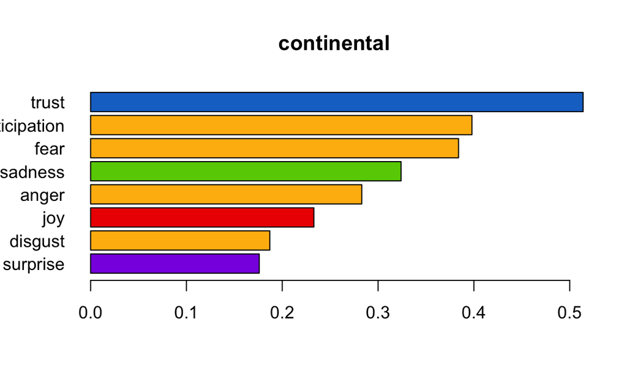

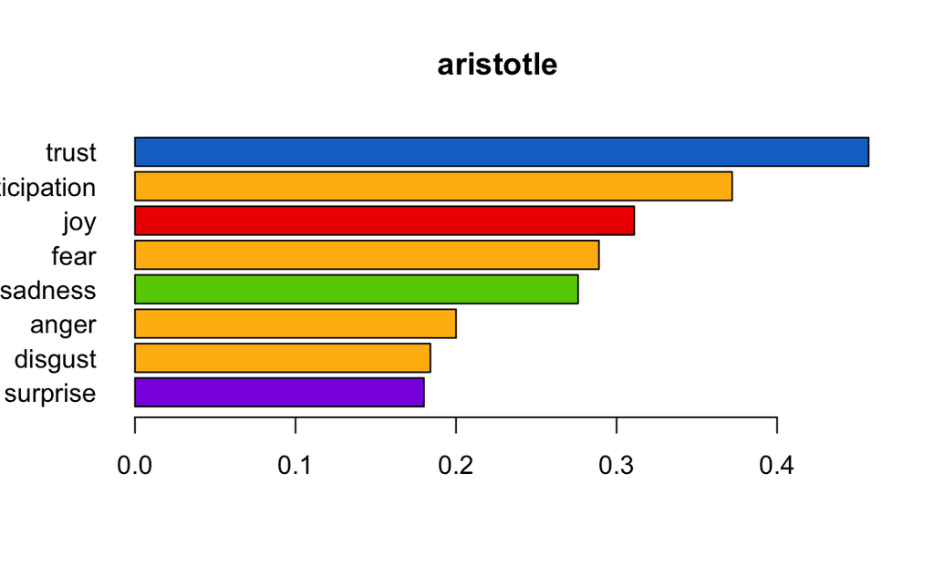

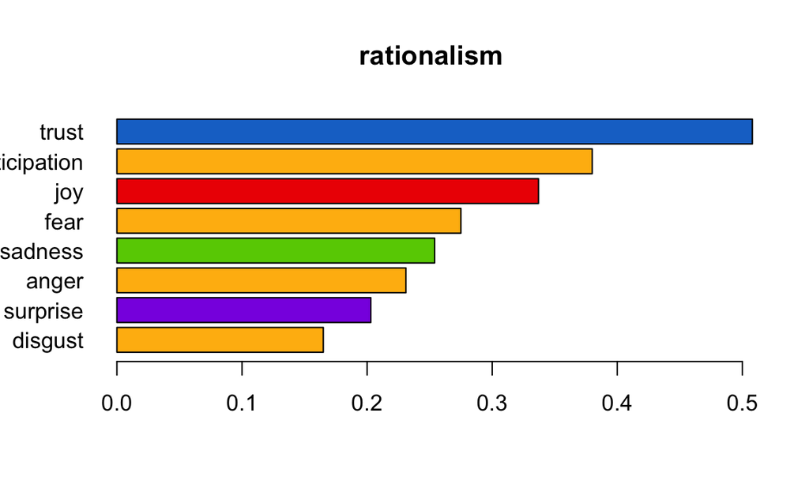

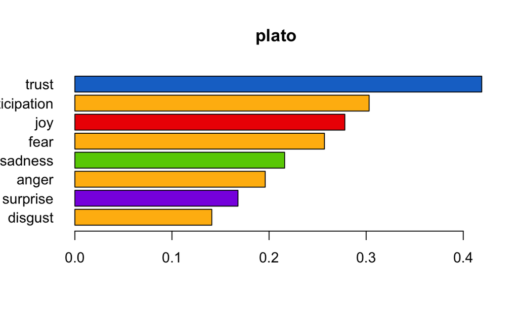

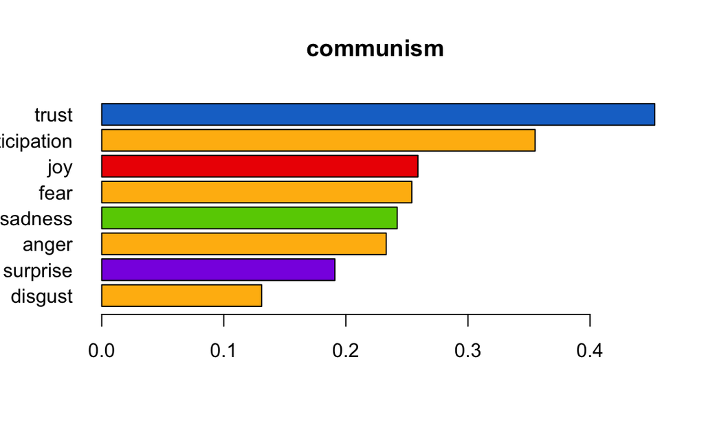

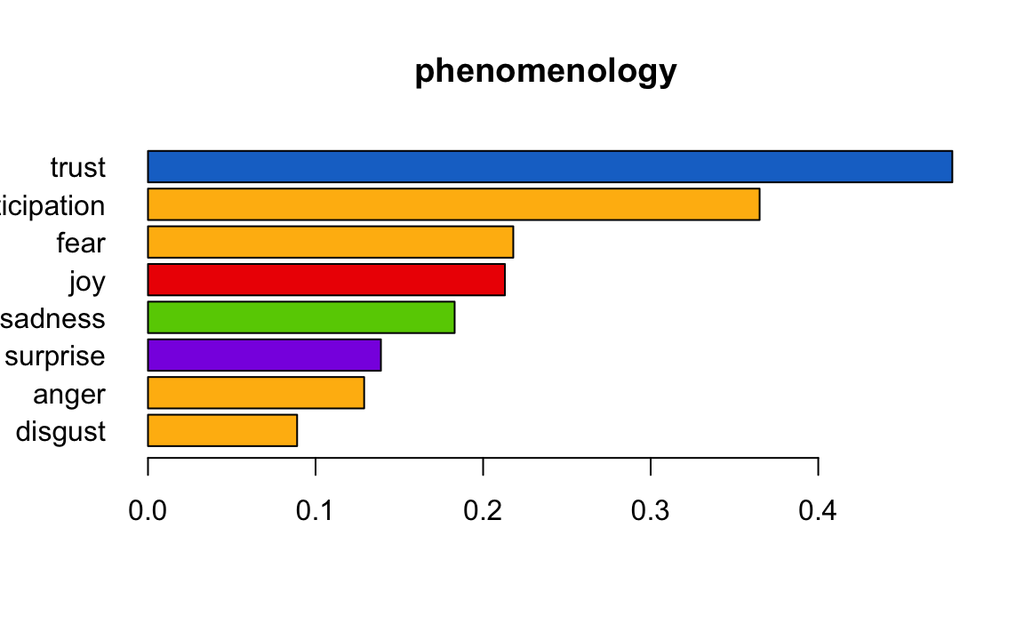

[1 more figures not shown]

I performed K-means clustering on emotion for all the 13 sampled philosophy schools.

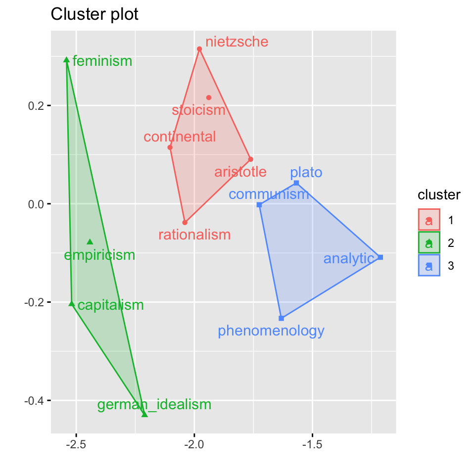

# Conclusion

In this blog, we discover how different ideas of philiosophy was focused according to human history and history events, what is the mean ideas of different school and what are the mean emotion of different schools. I believe furthur improvement could be made on clustering emotions of different authors and how does philisophy quote’s emotion reflect people’s feeling in the history.